# Assignment 1: Research Questions

Alicia Seeley, JT Keller, Alec Martinez

10/20/2021

# Research Question to Answer with Regression

Linear: How, if at all, is household income, property tax, and age related to neighborhood social ties?

Logistic: How, if at all, is housing tenure related to neighborhood social ties.

# Prior Research

We have identified two studies that show a positive relationship between housing tenure and different measures of social engagement. Levitten-Reid and Matthew (2018), using a sample from Canada, find “a positive association between home ownership and forms of bonding social capital”. Similarly, Werner and Klingborg (2010), in a study conducted of Stockholm, Sweden, found results indicating that “residents forming tenant-owners associations have more trust in neighbors in the neighborhood.”

# Sample Population and Variables

## Categorial Variables

### 1. Housing Tenure

### 2. Participated in a service or civic organization

### 3. Trust in People in Neighborhood

### 4. Frequency of talking to neighbors

### 5. Frequency of doing favors for neighbors and vice versa

## Continuous Variables

### 1. Household Income

### 2. Age

### 3. Property Taxes

# Data Import

## Load Libraries

```r
library(tidyverse)
library(tidycensus)
library(readxl)
library(knitr)
library(ipumsr)
library(survey)
library(srvyr)
```

```r
library(ggplot2)
library(gridExtra)
```

## Read in .dat file from IPUMS

```r
ddi <- read_ipums_ddi("cps_00004.xml")
data <- read_ipums_micro(ddi)
```

```
## Use of data from IPUMS CPS is subject to conditions including that users should
## cite the data appropriately. Use command `ipums_conditions()` for more details.
```

```r
kable(head(data))
```

| YEAR | SERIAL | MONTH | HWTFINL | CPSID | ASECFLAG | ASECWTH | HHTENURE | GQ | GQTYPE | HHINTYPE | METRO | METAREA | COUNTY | METFIPS | OWNERSHP | HHINCOME | PROPTAX | PUBHOUS | FAMINC | UNITSSTR | PERNUM | WTFINL | CPSIDP | ASECWT | AGE | SEX | CEORGCIV | CEORGCOM | CEFAVORS | … |
| --- | --- | --- | --- | --- | --- | --- | --- | --- | --- | --- | --- | --- | --- | --- | --- | --- | --- | --- | --- | --- | --- | --- | --- | --- | --- | --- | --- | --- | --- | --- |
| 2013 | 1 | 1 | 3617.522 | 2.01210e+13 | NA | NA | 1 | NA | 1 | 1 | 2 | 3440 | 0 | 26620 | NA | NA | NA | NA | 841 | NA | 1 | 3136.914 | 2.01210e+13 | NA | 79 | 1 | NA | NA | NA | … |
| 2013 | 1 | 1 | 3617.522 | 2.01210e+13 | NA | NA | 1 | NA | 1 | 1 | 2 | 3440 | 0 | 26620 | NA | NA | NA | NA | 841 | NA | 2 | 3617.522 | 2.01210e+13 | NA | 65 | 2 | NA | NA | NA | … |
| 2013 | 1 | 1 | 3617.522 | 2.01210e+13 | NA | NA | 1 | NA | 1 | 1 | 2 | 3440 | 0 | 26620 | NA | NA | NA | NA | 841 | NA | 3 | 3027.618 | 2.01210e+13 | NA | 28 | 2 | NA | NA | NA | … |
| 2013 | 2 | 1 | 3793.372 | 2.01201e+13 | NA | NA | 1 | NA | 1 | 1 | 2 | 3440 | 0 | 26620 | NA | NA | NA | NA | 720 | NA | 1 | 3011.946 | 2.01201e+13 | NA | 32 | 1 | NA | NA | NA | … |
| 2013 | 2 | 1 | 3793.372 | 2.01201e+13 | NA | NA | 1 | NA | 1 | 1 | 2 | 3440 | 0 | 26620 | NA | NA | NA | NA | 720 | NA | 2 | 3793.372 | 2.01201e+13 | NA | 33 | 2 | NA | NA | NA | … |
| 2013 | 3 | 1 | 2658.602 | 2.01212e+13 | NA | NA | 2 | NA | 6 | 1 | 2 | 1001 | 1073 | 13820 | NA | NA | NA | NA | 730 | NA | 1 | 2658.602 | 2.01212e+13 | NA | 54 | 1 | NA | NA | NA | … |

# Descriptive Statistics

## Continuous variables

The continuous variables in our study are 1) household income, 2) age, 3) property tax.

### Calculations

#### t tests (including confidence interval)

```r
income_t_test <- t.test(data$HHINCOME)
age_t_test <- t.test(data$AGE)
tax_t_test <- t.test(data$PROPTAX)
```

#### quantiles (including median and interquartile range)

```r
income_quartiles <- quantile(data$HHINCOME, na.rm = TRUE)
age_quartiles <- quantile(data$AGE, na.rm = TRUE)
tax_quartiles <- quantile(data$PROPTAX, na.rm = TRUE)
```

#### standard deviation

```r
income_sd <- sd(data$HHINCOME, na.rm = TRUE)
age_sd <- sd(data$AGE, na.rm = TRUE)
tax_sd <- sd(data$PROPTAX, na.rm = TRUE)
```

#### histograms

```r
income_hist <- ggplot(data) +
  geom_histogram(aes(x = HHINCOME)) +
  scale_x_continuous(trans = "log")

age_hist <- ggplot(data) +
  geom_histogram(aes(x = AGE))

tax_hist <- ggplot(data) +
  geom_histogram(aes(x = PROPTAX)) +
  scale_x_continuous(trans = "log")
```

### Displaying Data

```r
cont_summary <- tibble(
  Variable = c("Household income",
               "Age",
               "Property tax"),
  `Sample mean` = c(income_t_test$estimate,
                    age_t_test$estimate,
                    tax_t_test$estimate),
  `Population mean (95% confidence) - low` =
    c(income_t_test$conf.int[1],
      age_t_test$conf.int[1],
      tax_t_test$conf.int[1]),
  `Population mean (95% confidence) - high` =
    c(income_t_test$conf.int[2],
      age_t_test$conf.int[2],
      tax_t_test$conf.int[2]),
  Median = c(income_quartiles[3],
             age_quartiles[3],
             tax_quartiles[3]),
  `Interquartile range` = c(income_quartiles[4] - income_quartiles[2],
                            age_quartiles[4] - age_quartiles[2],
                            (tax_quartiles[4] - tax_quartiles[2])),
  `Standard deviation` = c(income_sd,
                          age_sd,
                          tax_sd))

kable(cont_summary, digits = 0)
```

| Variable | Sample mean | Population mean (95% confidence) - low | Population mean (95% confidence) - high | Median | Interquartile range | Standard deviation |
| --- | --- | --- | --- | --- | --- | --- |
| Household income | 83478 | 83080 | 83877 | 63440 | 73450 | 91507 |
| Age | 39 | 39 | 39 | 39 | 38 | 23 |
| Property tax | 2066 | 2050 | 2082 | 1100 | 2800 | 3704 |

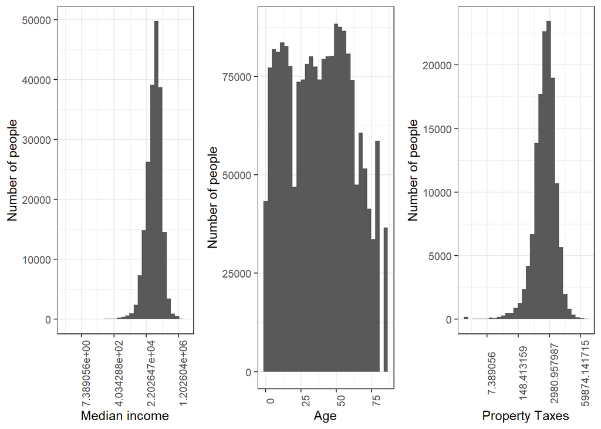

```r
pretty_income_hist <- income_hist +
  theme_bw() +
  scale_x_continuous(name = "Median income",
                     trans = "log") +
  scale_y_continuous(name = "Number of people") +
  theme(axis.text.x = element_text(angle = 90))
pretty_age_hist <- age_hist +
  theme_bw() +
  scale_x_continuous(name = "Age") +
  scale_y_continuous(name = "Number of people") +
  theme(axis.text.x = element_text(angle = 90))

pretty_tax_hist = tax_hist +
  theme_bw() +
  scale_x_continuous(name = "Property Taxes",
                     trans = "log") +
  scale_y_continuous(name = "Number of people") +
  theme(axis.text.x = element_text(angle = 90))
grid.arrange(pretty_income_hist, pretty_age_hist, pretty_tax_hist,
             ncol = 3)
```

```r
data <- data %>%
  mutate(HHTENURE1 = case_when(`HHTENURE` == 0 ~ "NIU",
                          `HHTENURE` == 1 ~ "Owned or being bought",
                          `HHTENURE` == 2 ~ "Rented for cash",
                          `HHTENURE` == 3 ~ "Occupied without payment or cash rent",
                          `HHTENURE` == 6 ~ "Refused",
                          `HHTENURE` == 7 ~ "Don't know",
                          TRUE ~ "unknown"))
```

```r
pct_tenure_owned <- t.test(data$HHTENURE1 == "Owned or being bought")
pct_tenure_rented <- t.test(data$HHTENURE1 == "Rented for cash")
pct_tenure_freeload <-t.test(data$HHTENURE1 == "Occupied without payment or cash rent")
pct_tenure_other <-t.test(data$HHTENURE1 == c("NIU", "Refused", "Don't Know"))
data <- data %>%
  mutate(CENEIGHCONF1 = case_when(`CENEIGHCONF` == 0 ~ "NIU",
                          `CENEIGHCONF` == 1 ~ "Trust none of the People",
                          `CENEIGHCONF` == 2 ~ "Trust some of the People",
                          `CENEIGHCONF` == 3 ~ "Trust most of the People",
                          `CENEIGHCONF` == 6 ~ "Trust all of the People",
                          `CENEIGHCONF` == 96 ~ "Refused",
                          `CENEIGHCONF` == 97 ~ "Don't know",
                          `CENEIGHCONF` == 98 ~ "No Response",
                          `CENEIGHCONF` == 99 ~ "NIU",
                          TRUE ~ "unknown"))
```

```r
pct_trust_none <- t.test(data$CENEIGHCONF1 == "Trust none of the People")
pct_trust_some <- t.test(data$CENEIGHCONF1 == "Trust some of the People")
pct_trust_most <- t.test(data$CENEIGHCONF1 == "Trust most of the People")
pct_trust_all <- t.test(data$CENEIGHCONF1 == "Trust all of the People")
pct_trust_other <- t.test(data$CENEIGHCONF1 == c("Refused", "Don't know", "No Response", "NIU", "unknown"))
```

```r
data <- data %>%
  mutate(CESOCIALIZE1 = case_when(`CESOCIALIZE` == 0 ~ "NIU",
                          `CESOCIALIZE` == 1 ~ "Not at all",
                          `CESOCIALIZE` == 2 ~ "Less than once a month",
                          `CESOCIALIZE` == 3 ~ "Once a month",
                          `CESOCIALIZE` == 4 ~ "A few times a month",
                          `CESOCIALIZE` == 5 ~ "A few times a week",
                          `CESOCIALIZE` == 6 ~ "Basically every day",
                          `CESOCIALIZE` == 96 ~ "Refused",
                          `CESOCIALIZE` == 97 ~ "Don't Know",
                          `CESOCIALIZE` == 98 ~ "No Response",
                          `CESOCIALIZE` == 99 ~ "NIU",
                          TRUE ~ "unknown"))
```

```r
pct_social_not <- t.test(data$CESOCIALIZE1 == "Not at all")
pct_social_less <- t.test(data$CESOCIALIZE1 == "Less than once a month")
pct_social_once <- t.test(data$CESOCIALIZE1 == "Once a month")
pct_social_few <- t.test(data$CESOCIALIZE1 == "A few times a month")
pct_social_week <- t.test(data$CESOCIALIZE1 == "A few times a week")
pct_social_day <- t.test(data$CESOCIALIZE1 == "Basically every day")
pct_social_other <- t.test(data$CESOCIALIZE1 == c("Refused", "Don't Know", "No Response", "NIU"))
```

```r
summary_tenure <-tibble(`Household Tenure` =
                              c("Owned or being bought",
                                "Rented for cash",
                                "Occupied without payment or cash rent",
                                "NIU, Refused, Don't know"),
                            `Sample proportion` =
                              c(pct_tenure_owned$estimate * 100,
                                pct_tenure_rented$estimate * 100,
                                pct_tenure_freeload$estimate * 100,
                                pct_tenure_other$estimate * 100),
                            `95-percent confidence - low` =
                              c(pct_tenure_owned$conf.int[1] * 100,
                                pct_tenure_rented$conf.int[1] * 100,
                                pct_tenure_freeload$conf.int[1] * 100,
                                pct_tenure_other$conf.int[1] * 100),
                            `95-percent confidence - high` =
                              c(pct_tenure_owned$conf.int[2] * 100,
                                pct_tenure_rented$conf.int[2] * 100,
                                pct_tenure_freeload$conf.int[2] * 100,
                                pct_tenure_other$conf.int[2] * 100))

kable(summary_tenure, digits = 2)
```

| Household Tenure | Sample proportion | 95-percent confidence - low | 95-percent confidence - high |
| --- | --- | --- | --- |
| Owned or being bought | 60.75 | 60.68 | 60.82 |
| Rented for cash | 26.52 | 26.46 | 26.58 |
| Occupied without payment or cash rent | 1.04 | 1.03 | 1.06 |
| NIU, Refused, Don’t know | 0.00 | NaN | NaN |

```r
summary_trust <-tibble(`Neighborhood Trust` =
                              c("Trust none of the people",
                                "Trust some of the people",
                                "Trust most of the people",
                                "Trust all of the people",
                                "Refused, Don't Know, No Response, NIU"),
                            `Sample proportion` =
                              c(pct_trust_none$estimate * 100,
                                pct_trust_some$estimate * 100,
                                pct_trust_most$estimate * 100,
                                pct_trust_all$estimate * 100,
                                pct_trust_other$estimate * 100),
                            `95-percent confidence - low` =
                              c(pct_trust_none$conf.int[1] * 100,
                                pct_trust_some$conf.int[1] * 100,
                                pct_trust_most$conf.int[1] * 100,
                                pct_trust_all$conf.int[1] * 100,
                                pct_trust_other$conf.int[1] * 100),
                            `95-percent confidence - high` =
                              c(pct_trust_none$conf.int[2] * 100,
                                pct_trust_some$conf.int[2] * 100,
                                pct_trust_most$conf.int[2] * 100,
                                pct_trust_all$conf.int[2] * 100,
                                pct_trust_other$conf.int[2] * 100))

kable(summary_trust, digits = 2)
```

| Neighborhood Trust | Sample proportion | 95-percent confidence - low | 95-percent confidence - high |
| --- | --- | --- | --- |
| Trust none of the people | 0.10 | 0.09 | 0.10 |
| Trust some of the people | 0.41 | 0.40 | 0.42 |
| Trust most of the people | 0.53 | 0.52 | 0.54 |
| Trust all of the people | 0.00 | NaN | NaN |
| Refused, Don’t Know, No Response, NIU | 19.79 | 19.73 | 19.84 |

```r
summary_social <-tibble(`Social Neighbors` =
                              c("Not at all",
                                "Less than once a month",
                                "Once a month",
                                "A few times a month",
                                "A few times a week",
                                "Basically every day",
                                "Refused, Don't Know, No Response, NIU"),
                            `Sample proportion` =
                              c(pct_social_not$estimate * 100,
                                pct_social_less$estimate * 100,
                                pct_social_once$estimate * 100,
                                pct_social_few$estimate * 100,
                                pct_social_week$estimate * 100,
                                pct_social_day$estimate * 100,
                                pct_social_other$estimate * 100),
                            `95-percent confidence - low` =
                              c(pct_social_not$conf.int[1] * 100,
                                pct_social_less$conf.int[1] * 100,
                                pct_social_once$conf.int[1] * 100,
                                pct_social_few$conf.int[1] * 100,
                                pct_social_week$conf.int[1] * 100,
                                pct_social_day$conf.int[1] * 100,
                                pct_social_other$conf.int[1] * 100),
                            `95-percent confidence - high` =
                              c(pct_social_not$conf.int[2] * 100,
                                pct_social_less$conf.int[2] * 100,
                                pct_social_once$conf.int[2] * 100,
                                pct_social_few$conf.int[2] * 100,
                                pct_social_week$conf.int[2] * 100,
                                pct_social_day$conf.int[2] * 100,
                                pct_social_other$conf.int[2] * 100))

kable(summary_social, digits = 2)
```

| Social Neighbors | Sample proportion | 95-percent confidence - low | 95-percent confidence - high |
| --- | --- | --- | --- |
| Not at all | 0.23 | 0.23 | 0.24 |
| Less than once a month | 0.21 | 0.20 | 0.22 |
| Once a month | 0.17 | 0.16 | 0.17 |
| A few times a month | 0.41 | 0.40 | 0.42 |
| A few times a week | 0.54 | 0.53 | 0.55 |
| Basically every day | 0.22 | 0.21 | 0.22 |
| Refused, Don’t Know, No Response, NIU | 1.17 | 1.16 | 1.19 |

The bucket for “unknown” - which includes respondents who refused to answer or responded ‘don’t know’ - represents over 90% of the data for the two categorical measures of social ties (trust in neighbors; conversations with neighbors). This might render the dataset meaningless for our purposes, unless we are able to remove the “unknown” data points from the analysis and go with that significantly smaller n value….

# References

Werner, Inga Britt, and Kerstin Klingborg. “Studying Social Capital In Housing Neighborhoods-Does Tenure Matter?.” (2010).

Leviten-Reid, Catherine, and Rebecca A. Matthew. “Housing tenure and neighbourhood social capital.” Housing, Theory and Society 35, no. 3 (2018): 300-328.

Sarah Flood, Miriam King, Renae Rodgers, Steven Ruggles, J. Robert Warren and Michael Westberry. Integrated Public Use Microdata Series, Current Population Survey: Version 9.0 [dataset]. Minneapolis, MN: IPUMS, 2021. https://doi.org/10.18128/D030.V9.0